# Train Model

It is finally time to use the features we have created to train some classifiers to predict Physics Nobel Laureates. We will be training the following classifiers:

- [Logistic Regression](https://en.wikipedia.org/wiki/Logistic_regression)
- [Support Vector Machine](https://en.wikipedia.org/wiki/Support_vector_machine)
- [Random Forest](https://en.wikipedia.org/wiki/Random_forest)

These classifiers are chosen due to their simplicity, appropriateness for the input features and target data types, ease of interpretability and their well-established performance on a range of classification tasks.

We will be selecting [hyperparameters](https://en.wikipedia.org/wiki/Hyperparameter) by evaluating the performance of the models on the validation set. This will be done in a principled manner using a couple of performance measures. The first of these, the [Matthews Correlation Coefficient (MCC)](https://en.wikipedia.org/wiki/Matthews_correlation_coefficient), you have already seen during the creation of our baseline model. We will discuss the second measure in detail, and explain why it is needed, when we get to that point. OK let's get going!

```python
import ast
import operator
import warnings

import matplotlib.pyplot as plt
import numpy as np
import pandas as pd
from sklearn.ensemble import RandomForestClassifier
from sklearn.linear_model import LogisticRegression
from sklearn.metrics import classification_report
from sklearn.metrics import confusion_matrix
from sklearn.metrics import matthews_corrcoef
from sklearn.model_selection import ParameterGrid
from sklearn.model_selection import ParameterSampler
from sklearn.preprocessing import MinMaxScaler
from sklearn.svm import SVC

from src.data.progress_bar import progress_bar
from src.features.features_utils import convert_categoricals_to_numerical
from src.features.features_utils import convert_target_to_numerical
from src.models.metrics_utils import confusion_matrix_to_dataframe
from src.models.metrics_utils import mcc_auc_score
from src.models.metrics_utils import mcc_curve

%matplotlib inline
```

## Reading in the Data

First let's read in both sets of training and validation features and targets. We will also read in the sample weights that we created for covariate shift adaptation. Also let's convert the categorical fields to a numerical form that is suitable for building machine learning models.

```python
train_features = pd.read_csv('../data/processed/train-features.csv')
X_train = convert_categoricals_to_numerical(train_features)
X_train.head()
```

| full_name | alumnus_in_** | alumnus_in_*** | alumnus_in_AS | alumnus_in_AUS | alumnus_in_AUT | alumnus_in_CHE | alumnus_in_DEU | alumnus_in_EU | alumnus_in_FRA | alumnus_in_GBR | ... | worked_in_CHE | worked_in_DEU | worked_in_EU | worked_in_FRA | worked_in_GBR | worked_in_ITA | worked_in_NA | worked_in_NLD | worked_in_RUS | worked_in_USA |
| --- | --- | --- | --- | --- | --- | --- | --- | --- | --- | --- | --- | --- | --- | --- | --- | --- | --- | --- | --- | --- | --- |
| Aage Bohr | 0 | 1 | 0 | 0 | 0 | 0 | 0 | 1 | 0 | 0 | ... | 0 | 0 | 1 | 0 | 1 | 0 | 1 | 0 | 0 | 1 |
| Aaldert Wapstra | 0 | 0 | 0 | 0 | 0 | 0 | 0 | 0 | 0 | 0 | ... | 0 | 0 | 0 | 0 | 0 | 0 | 0 | 0 | 0 | 0 |
| Abdus Salam | 0 | 1 | 1 | 0 | 0 | 0 | 0 | 1 | 0 | 1 | ... | 0 | 0 | 0 | 0 | 0 | 0 | 0 | 0 | 0 | 0 |
| Abraham Alikhanov | 0 | 0 | 0 | 0 | 0 | 0 | 0 | 1 | 0 | 0 | ... | 0 | 0 | 1 | 0 | 0 | 0 | 0 | 0 | 1 | 0 |
| Abraham H. Taub | 0 | 0 | 0 | 0 | 0 | 0 | 0 | 0 | 0 | 0 | ... | 0 | 0 | 0 | 0 | 0 | 0 | 0 | 0 | 0 | 0 |

5 rows × 202 columns

```python
sample_weights = pd.read_csv('../models/train-features-sample-weights.csv')
sample_weights.head()
```

|  | full_name | weight |
| --- | --- | --- |
| 0 | Aage Bohr | 0.000252 |
| 1 | Aaldert Wapstra | 2.662827 |
| 2 | Abdus Salam | 0.000340 |
| 3 | Abraham Alikhanov | 0.000700 |
| 4 | Abraham H. Taub | 1.056121 |

```python
train_features_topics = pd.read_csv('../data/processed/train-features-topics.csv')
X_train_topics = convert_categoricals_to_numerical(train_features_topics)
X_train_topics.head()
```

| full_name | is_eu_worker | is_eu_alumni | is_alumni | is_na_eu_resident | is_na_citizen | is_na_worker | is_as_citizen | is_na_alumni | is_gbr_citizen | is_rus_citizen | ... | is_eu_citizen | is_gbr_worker | is_passport_collector | is_born | is_fra_citizen | is_other_citizen | is_emigrant | is_physics_laureate_teacher | is_physics_laureate_student | is_astronomer |
| --- | --- | --- | --- | --- | --- | --- | --- | --- | --- | --- | --- | --- | --- | --- | --- | --- | --- | --- | --- | --- | --- |
| Aage Bohr | 1 | 1 | 1 | 0 | 0 | 1 | 0 | 0 | 0 | 0 | ... | 1 | 1 | 0 | 1 | 0 | 1 | 0 | 0 | 0 | 0 |
| Aaldert Wapstra | 0 | 0 | 0 | 0 | 0 | 0 | 0 | 0 | 0 | 0 | ... | 1 | 0 | 0 | 0 | 0 | 0 | 0 | 0 | 0 | 0 |
| Abdus Salam | 0 | 1 | 1 | 0 | 0 | 0 | 1 | 0 | 1 | 0 | ... | 0 | 0 | 0 | 1 | 0 | 1 | 0 | 0 | 0 | 1 |
| Abraham Alikhanov | 1 | 1 | 1 | 0 | 0 | 0 | 1 | 0 | 0 | 1 | ... | 0 | 0 | 0 | 1 | 0 | 1 | 0 | 0 | 0 | 1 |
| Abraham H. Taub | 0 | 0 | 1 | 0 | 1 | 0 | 0 | 1 | 0 | 0 | ... | 0 | 0 | 0 | 1 | 0 | 0 | 0 | 0 | 0 | 0 |

5 rows × 25 columns

```python
sample_weights_topics = pd.read_csv('../models/train-features-topics-sample-weights.csv')
sample_weights_topics.head()
```

|  | full_name | weight |
| --- | --- | --- |
| 0 | Aage Bohr | 0.143701 |
| 1 | Aaldert Wapstra | 2.555106 |
| 2 | Abdus Salam | 0.082660 |
| 3 | Abraham Alikhanov | 0.013562 |
| 4 | Abraham H. Taub | 2.798886 |

```python
train_target = pd.read_csv('../data/processed/train-target.csv', index_col='full_name', squeeze=True)
y_train = convert_target_to_numerical(train_target)
y_train.head()
```

```
full_name
Aage Bohr            1
Aaldert Wapstra      0
Abdus Salam          1
Abraham Alikhanov    0
Abraham H. Taub      0
Name: physics_laureate, dtype: int64
```

```python
validation_features = pd.read_csv('../data/processed/validation-features.csv')
X_validation = convert_categoricals_to_numerical(validation_features)
X_validation.head()
```

| full_name | alumnus_in_** | alumnus_in_*** | alumnus_in_AS | alumnus_in_AUS | alumnus_in_AUT | alumnus_in_CHE | alumnus_in_DEU | alumnus_in_EU | alumnus_in_FRA | alumnus_in_GBR | ... | worked_in_CHE | worked_in_DEU | worked_in_EU | worked_in_FRA | worked_in_GBR | worked_in_ITA | worked_in_NA | worked_in_NLD | worked_in_RUS | worked_in_USA |
| --- | --- | --- | --- | --- | --- | --- | --- | --- | --- | --- | --- | --- | --- | --- | --- | --- | --- | --- | --- | --- | --- |
| Abdul Qadeer Khan | 0 | 1 | 0 | 0 | 0 | 0 | 1 | 1 | 0 | 0 | ... | 0 | 1 | 1 | 0 | 1 | 0 | 0 | 1 | 0 | 0 |
| Alain Haché | 0 | 1 | 0 | 0 | 0 | 0 | 0 | 0 | 0 | 0 | ... | 0 | 0 | 0 | 0 | 0 | 0 | 1 | 0 | 0 | 0 |
| Alan Andrew Watson | 0 | 0 | 0 | 0 | 0 | 0 | 0 | 1 | 0 | 1 | ... | 0 | 0 | 1 | 0 | 1 | 0 | 0 | 0 | 0 | 0 |
| Alan Guth | 0 | 0 | 0 | 0 | 0 | 0 | 0 | 0 | 0 | 0 | ... | 0 | 0 | 0 | 0 | 0 | 0 | 0 | 0 | 0 | 0 |
| Albert Fert | 0 | 0 | 0 | 0 | 0 | 0 | 0 | 1 | 1 | 0 | ... | 0 | 0 | 1 | 1 | 0 | 0 | 1 | 0 | 0 | 1 |

5 rows × 202 columns

```python
validation_features_topics = pd.read_csv('../data/processed/validation-features-topics.csv')
X_validation_topics = convert_categoricals_to_numerical(validation_features_topics)
X_validation_topics.head()
```

| full_name | is_eu_worker | is_eu_alumni | is_alumni | is_na_eu_resident | is_na_citizen | is_na_worker | is_as_citizen | is_na_alumni | is_gbr_citizen | is_rus_citizen | ... | is_eu_citizen | is_gbr_worker | is_passport_collector | is_born | is_fra_citizen | is_other_citizen | is_emigrant | is_physics_laureate_teacher | is_physics_laureate_student | is_astronomer |
| --- | --- | --- | --- | --- | --- | --- | --- | --- | --- | --- | --- | --- | --- | --- | --- | --- | --- | --- | --- | --- | --- |
| Abdul Qadeer Khan | 1 | 1 | 1 | 1 | 0 | 0 | 1 | 0 | 0 | 0 | ... | 0 | 1 | 0 | 1 | 0 | 1 | 0 | 0 | 0 | 0 |
| Alain Haché | 1 | 0 | 1 | 1 | 1 | 0 | 0 | 0 | 0 | 0 | ... | 0 | 0 | 0 | 1 | 0 | 1 | 0 | 0 | 0 | 0 |
| Alan Andrew Watson | 1 | 1 | 1 | 1 | 0 | 0 | 0 | 0 | 1 | 0 | ... | 1 | 1 | 0 | 0 | 0 | 0 | 0 | 0 | 0 | 1 |
| Alan Guth | 0 | 0 | 1 | 1 | 1 | 0 | 0 | 1 | 0 | 0 | ... | 0 | 0 | 0 | 1 | 0 | 0 | 0 | 0 | 0 | 1 |
| Albert Fert | 1 | 1 | 1 | 1 | 0 | 1 | 0 | 0 | 0 | 0 | ... | 1 | 0 | 0 | 1 | 1 | 0 | 0 | 0 | 0 | 0 |

5 rows × 25 columns

```python
validation_target = pd.read_csv('../data/processed/validation-target.csv', index_col='full_name',
                                squeeze=True)
y_validation = convert_target_to_numerical(validation_target)
y_validation.head()
```

```
full_name
Abdul Qadeer Khan     0
Alain Haché           0
Alan Andrew Watson    0
Alan Guth             0
Albert Fert           1
Name: physics_laureate, dtype: int64
```

## Hyperparameter Selection

The hyperparameters of the models that we will be fitting are critical to their predictive performance. We will use [grid search](https://en.wikipedia.org/wiki/Hyperparameter_optimization#Grid_search) to select them in a principled manner. The optimal hyperparameter values will be chosen according to the set of values that maximize the MCC on the validation set. The function below will be used to accomplish this task.

```python
def evaluate_classifier(
    X_train, y_train, X_validation, y_validation, clf=LogisticRegression(),
    param_grid=ParameterGrid(dict(C=np.logspace(-5, 15, 21, base=2.0))), score_func=matthews_corrcoef,
    greater_score_is_better=True, solver='lbfgs', sample_weight=None, max_iter=1000,
    random_state=None, n_jobs=None, name='classifier', progress_bar=None):

    """Evaluate an `sklearn` classifier over a parameter grid using a scoring function.

    Args:
        X_train ({array-like, sparse matrix}, shape (n_samples, n_features)): Training features matrix,
            where n_samples is the number of samples and n_features is the number of features.
        y_train (array-like, shape (n_samples,)): Training data target vector.
        X_validation ({array-like, sparse matrix}, shape (n_samples, n_features)): Validation features
        matrix, where n_samples is the number of samples and n_features is the number of features.
        y_validation (array-like, shape (n_samples,)): Validation data target vector.
        clf (sklearn.base.BaseEstimator, optional): Defaults to LogisticRegression(). Classifier.
        param_grid (sklearn.model_selection.ParameterGrid, optional): Defaults to
            ParameterGrid(dict(C=np.logspace(-5, 15, 21, base=2.0))). Grid of parameters with a discrete
            number of values for each.
        score_func (callable, optional): Defaults to matthews_corrcoef. Score function (or loss function)
            with signature score_func(y, y_pred, **kwargs).
        greater_score_is_better (bool, optional): Defaults to True. Whether score_func is a score function
            (default), meaning high is good, or a loss function, meaning low is good. In the latter case,
            the scorer object will sign-flip the outcome of the score_func.
        solver (str, optional): Defaults to 'lbfgs'. Algorithm to use in the optimization problem.
        sample_weight (array-like, shape (n_samples,), optional): Defaults to None. Array of weights
            that are assigned to individual samples. If not provided, then each sample is given unit
            weight.
        max_iter (int, optional): Defaults to 1000. Maximum number of iterations taken for the solvers
            to converge.
        random_state (int, RandomState instance or None, optional): Defaults to None. The seed of the
            pseudo random number generator to use when shuffling the data.
        n_jobs (int or None, optional): Defaults to None. Number of CPU cores used when parallelizing.
            None means 1 unless in a joblib.parallel_backend context. -1 means using all processors.
        name (str, optional): Defaults to 'classifier'. Name of classifier.
        progress_bar (progressbar.ProgressBar, optional): Defaults to None. Progress bar.

    Returns:
        dict: Results containing the name, best classifier estimator, best parameters, best score,
            training scores, and validation scores.

    Raises:
        NotImplementedError: If classifier is not LogisticRegression, SVC or RandomForestClassifier.

        """

    if progress_bar:
        progress_bar.start()

    train_scores = {}
    validation_scores = {}
    classifiers = {}
    num_iters = 0
    for params in param_grid:

        num_iters += 1
        if progress_bar:
            progress_bar.update(num_iters)

        # fit the model to training set
        if isinstance(clf, LogisticRegression):
            classifier = LogisticRegression(
                penalty=params.get('penalty', 'l2'), C=params.get('C', 1.0), solver=solver,
                random_state=random_state, class_weight=params.get('class_weight'), max_iter=max_iter)
        elif isinstance(clf, SVC):
            classifier = SVC(
                C=params.get('C', 1.0), kernel=params.get('kernel', 'rbf'),
                gamma=params.get('gamma', 'auto_deprecated'), random_state=random_state,
                class_weight=params.get('class_weight'), max_iter=max_iter)
        elif isinstance(clf, RandomForestClassifier):
            classifier = RandomForestClassifier(
                n_estimators=params.get('n_estimators', 'warn'),
                max_features=params.get('max_features', 'auto'),
                min_samples_leaf=params.get('min_samples_leaf', 1), random_state=random_state,
                class_weight=params.get('class_weight'), n_jobs=n_jobs)
        else:
            raise NotImplementedError
        classifier.fit(X_train, y_train, sample_weight=sample_weight)
        classifiers[str(params)] = classifier

        # predict on validation set and evaluate scores
        y_train_predict = classifier.predict(X_train)
        y_validation_predict = classifier.predict(X_validation)
        with warnings.catch_warnings():  # ignore runtime warnings caused by zero MCC
            warnings.filterwarnings('ignore', category=RuntimeWarning)
            train_scores[str(params)] = score_func(y_true=y_train, y_pred=y_train_predict)
            validation_scores[str(params)] = score_func(y_true=y_validation,
                                                        y_pred=y_validation_predict)

    if progress_bar:
        progress_bar.finish()

    # find the best scoring model
    sorted_validation_scores = sorted(
        validation_scores.items(), key=operator.itemgetter(1), reverse=greater_score_is_better)
    best_params = ast.literal_eval(sorted_validation_scores[0][0])
    best_score = sorted_validation_scores[0][1]
    best_classifier = classifiers[str(best_params)]

    # issue warning about LogisticRegression classifiers with infeasibly large or small coefficients
    # (corresponds to odds lower than p = 0.001 or larger than p = 0.999)
    # see https://stats.idre.ucla.edu/other/mult-pkg/faq/general/faq-how-do-i-interpret-odds-ratios-in-logistic-regression/
    if isinstance(best_classifier, LogisticRegression):
        odds_ratio = np.exp(best_classifier.coef_.ravel())
        max_odds_ratio = np.max(odds_ratio)
        if max_odds_ratio > 0.999 / (1.0 - 0.999):
            print('Warning: The best classifier Logistic regression coefficients are infeasibly large. '
                  'The maximum odds ratio is {}-1.'.format(max_odds_ratio))

    # return results
    results = dict(name=name, best_classifier=best_classifier, best_params=best_params,
                   best_score=best_score, train_scores=train_scores, validation_scores=validation_scores)
    return results


def print_best_classifier(results):
    """Print the best classifier.

    Args:
        results (dict): Results of classifier evaluation.
    """

    print(results['name'])
    print('Best params: ', results['best_params'])
    print('Training score: ', round(results['train_scores'][str(results['best_params'])], 3))
    print('Validation score: ', round(results['best_score'], 3))
```

It's now time to select the best parameters for the two feature sets with and without the sample weights.

### Logistic Regression (LR)

Let's perform the grid search now.

```python
penalty = ['l1', 'l2']
Cs= np.logspace(-5, 15, 21, base=2.0)
class_weight = ([{0: weight, 1: 1.0 - weight} for weight in np.linspace(0.0, 1.0, 21)] +
                 [{0: 1.0, 1: 1.0}] + ['balanced'])
param_grid = ParameterGrid(dict(penalty=penalty, C=Cs, class_weight=class_weight))

clf = LogisticRegression()
solver = 'liblinear'
bar = progress_bar(len(param_grid), banner_text_begin='Running: ', banner_text_end=' param sets')
```

```python
logit_results = evaluate_classifier(
    X_train, y_train, X_validation, y_validation, clf=clf, param_grid=param_grid, solver=solver,
    random_state=0, name='LR', progress_bar=bar)
print_best_classifier(logit_results)
```

```
Running: 966 / 966 param sets |█████| 100% Elapsed Time: 0:00:43 Time:  0:00:43
```

```
LR
Best params:  {'C': 2.0, 'class_weight': {0: 0.1, 1: 0.9}, 'penalty': 'l2'}
Training score:  0.662
Validation score:  0.494
```

```python
logit_results_weights = evaluate_classifier(
    X_train, y_train, X_validation, y_validation, clf=clf, param_grid=param_grid, solver=solver,
    sample_weight=sample_weights['weight'], random_state=1, name='LR + sample weights', progress_bar=bar)
print_best_classifier(logit_results_weights)
```

```
Running: 966 / 966 param sets |█████| 100% Elapsed Time: 0:00:25 Time:  0:00:25
```

```
Warning: The best classifier Logistic regression coefficients are infeasibly large. The maximum odds ratio is 16335096828.810358-1.
LR + sample weights
Best params:  {'C': 16384.0, 'class_weight': {0: 0.15000000000000002, 1: 0.85}, 'penalty': 'l1'}
Training score:  0.723
Validation score:  0.522
```

From the warning message it is clear that the odds ratio is impractically large and consequently we cannot trust the model. This appears to be caused by some combination of `sample_weight` and `class_weight`. Note that the above warning appears for all values of the `class_weight` parameter when $L1$ regularization is used. It does not appear when $L2$ regularization is used. Furthermore, the performance of the model is independent of the `class_weight` under $L2$ regularization. So let's try again excluding these parameters from the grid search ($L2$ regularization is used by default).

```python
logit_results_weights = evaluate_classifier(
    X_train, y_train, X_validation, y_validation, clf=clf, param_grid=ParameterGrid(dict(C=Cs)),
    solver=solver, sample_weight=sample_weights['weight'], random_state=1, name='LR + sample weights',
    progress_bar=bar)
print_best_classifier(logit_results_weights)
```

```
Running: 966 / 966 param sets |█████| 100% Elapsed Time: 0:00:00 Time:  0:00:00
```

```
LR + sample weights
Best params:  {'C': 8.0}
Training score:  0.554
Validation score:  0.449
```

OK this looks much better now.

```python
logit_results_topics = evaluate_classifier(
    X_train_topics, y_train, X_validation_topics, y_validation, clf=clf, param_grid=param_grid,
    solver=solver, random_state=2, name='LR (topics)', progress_bar=bar)
print_best_classifier(logit_results_topics)
```

```
Running: 966 / 966 param sets |█████| 100% Elapsed Time: 0:00:19 Time:  0:00:19
```

```
LR (topics)
Best params:  {'C': 32.0, 'class_weight': {0: 0.2, 1: 0.8}, 'penalty': 'l1'}
Training score:  0.423
Validation score:  0.494
```

```python
logit_results_topics_weights = evaluate_classifier(
    X_train_topics, y_train, X_validation_topics, y_validation, clf=clf, param_grid=param_grid,
    solver=solver, sample_weight=sample_weights_topics['weight'], random_state=3,
    name='LR (topics) + sample weights', progress_bar=bar)
print_best_classifier(logit_results_topics_weights)
```

```
Running: 966 / 966 param sets |█████| 100% Elapsed Time: 0:00:20 Time:  0:00:20
```

```
LR (topics) + sample weights
Best params:  {'C': 512.0, 'class_weight': {0: 0.25, 1: 0.75}, 'penalty': 'l2'}
Training score:  0.398
Validation score:  0.472
```

We can make the following observations about the results:

- All of the models selected a much larger `class_weight` for the positive class than the negative class (except for the model where we excluded this hyperparameter from the grid search). It seems like the choice of this hyperparamter is important.
- Models fitted with the original features are overfitting and those with the topics features are underfitting (the validation MCC's are higher than the training MCCs).
- Applying strong regularization does not improve performance for the original features.

### Support Vector Machine (SVM)

The hyperparameters to be selected for the support vector machine model are:

- The regularization parameter `C` of the error term. This parameter trades off correct classification of training examples against maximization of the separating hyperplane's margin. For larger values of `C`, a smaller margin will be accepted if the separating hyperplane is better at classifying training points correctly. Lower values of `C` encourage a larger margin at the cost of misclassifying more training points.
- `class_weight`, as defined above for logistic regression.

Note that the `kernel` parameter, which is used to specify the kernel type to be used in the algorithm, will be fixed as the *linear* kernel. The reason for not considering the *RBF* or *poly* kernels is interpretability of the model. For the *RBF* and *poly* kernels, the [separating hyperplane and the weights that define it exist in a transformed space](https://stackoverflow.com/questions/21260691/how-to-obtain-features-weights) that is not directly related to the input feature space. OK let's perform the grid search now.

```python
Cs = np.logspace(-5, 10, 16, base=2.0)
class_weight = ([{0: weight, 1: 1.0 - weight} for weight in np.linspace(0.0, 1.0, 21)] +
                 [{0: 1.0, 1: 1.0}] + ['balanced'])
param_grid = ParameterGrid(dict(kernel=['linear'], C=Cs, class_weight=class_weight))

clf=SVC()
max_iter = -1
bar = progress_bar(len(param_grid), banner_text_begin='Running: ', banner_text_end=' param sets')
```

```python
svm_results = evaluate_classifier(
    X_train, y_train, X_validation, y_validation, clf=clf, param_grid=param_grid, random_state=4,
    max_iter=max_iter, name='SVM', progress_bar=bar)
print_best_classifier(svm_results)
```

```
Running: 368 / 368 param sets |█████| 100% Elapsed Time: 0:00:31 Time:  0:00:31
```

```
SVM
Best params:  {'C': 0.0625, 'class_weight': {0: 0.2, 1: 0.8}, 'kernel': 'linear'}
Training score:  0.602
Validation score:  0.518
```

```python
svm_results_weights = evaluate_classifier(
    X_train, y_train, X_validation, y_validation, clf=clf, param_grid=param_grid,
    sample_weight=sample_weights['weight'], random_state=5, max_iter=max_iter,
    name='SVM + sample weights', progress_bar=bar)
print_best_classifier(svm_results_weights)
```

```
Running: 368 / 368 param sets |█████| 100% Elapsed Time: 0:00:23 Time:  0:00:23
```

```
SVM + sample weights
Best params:  {'C': 32.0, 'class_weight': {0: 0.4, 1: 0.6}, 'kernel': 'linear'}
Training score:  0.622
Validation score:  0.557
```

```python
svm_results_topics = evaluate_classifier(
    X_train_topics, y_train, X_validation_topics, y_validation, clf=clf, param_grid=param_grid,
    random_state=6, max_iter=max_iter, name='SVM (topics)', progress_bar=bar)
print_best_classifier(svm_results_topics)
```

```
Running: 368 / 368 param sets |█████| 100% Elapsed Time: 0:00:11 Time:  0:00:11
```

```
SVM (topics)
Best params:  {'C': 1.0, 'class_weight': 'balanced', 'kernel': 'linear'}
Training score:  0.408
Validation score:  0.489
```

```python
svm_results_topics_weights = evaluate_classifier(
    X_train_topics, y_train, X_validation_topics, y_validation, clf=clf, param_grid=param_grid,
    sample_weight=sample_weights_topics['weight'], random_state=7, max_iter=max_iter,
    name='SVM (topics) + sample weights', progress_bar=bar)
print_best_classifier(svm_results_topics_weights)
```

```
Running: 368 / 368 param sets |█████| 100% Elapsed Time: 0:00:05 Time:  0:00:05
```

```
SVM (topics) + sample weights
Best params:  {'C': 512.0, 'class_weight': 'balanced', 'kernel': 'linear'}
Training score:  0.386
Validation score:  0.366
```

We can make the following observations about the results:

- Once again, since all of the models selected a larger `class_weight` for the positive class than the negative class, we can see that the choice of this hyperparameter is very important. Interestingly, the balanced `class_weight` is chosen for the topics features.
- Again we see overfitting and underfitting of the models. However, for the classifiers fitted with the sample weights, the effect is far less pronounced than for the logistic regression models.
- The sample-weighted classifiers seem to favor larger values of C (i.e. smaller margin) whereas the unweighted ones facvor smaller values of C (i.e larger margin).

### Random Forest (RF)

There are a multitude of hyperparameters that can be selected for a random forest model. The hyperparameters control the randomness of the forest. The aim is to set them such that reasonable predictive power of individual trees is achieved without excessive correlation between the trees (i.e. bias-variance trade-off). Based on the advice of *Probst et al.* in [Hyperparameters and Tuning Strategies for Random Forest](https://arxiv.org/pdf/1804.03515.pdf), we will restrict ourselves to the following most influential hyperparameters:

- The number of features `max_features` to consider when looking for the best split. Lower values lead to more diverse and less correlated trees, which results in more stable aggregation of predictions. However, lower values also lead to the individual trees being weaker predictors of the target variable.
- The minimum number of samples required to be at a leaf node `min_samples_leaf`. Lower values lead to trees of larger depth, which means that more splits are performed until the terminal nodes. More splits means the model is more complex and this can potentially lead to overfitting.
- `class_weight`, as defined above for logistic regression.

Note that the number of trees in the forest `n_estimators` will be fixed at 500. Following the recommendations of *Probst et al.*, "the number of trees should be set high: the higher the number of trees, the better the results in terms of performance and precision of variable importances. However, the improvement obtained by adding trees diminishes as more and more trees are added." 500 trees in the forest seems like a reasonable compromise based on the stability of the solution and computational resources available.

Let's perform the grid search now. Note that this takes a considerable amount of time due to the number of trees in the forest and the large hyperparameter space being searched. To reduce the computation time, we will perform a **random search** over one-quarter of the values in the hyperparameter space, by drawing randomly from a uniform distribution. *Bergstra and Bengio* show in [Random Search for Hyper-Parameter Optimization](http://www.jmlr.org/papers/volume13/bergstra12a/bergstra12a.pdf) that for neural networks, random search is more efficient in searching good hyperparameter specifications than grid search.

```python
n_estimators = [500]
max_features = [0.01] + list(np.linspace(0.05, 0.95, 7)) + ['sqrt', None]
min_samples_leaf = np.logspace(0, 6, 7, base=2.0).astype('int64')

class_weight = ([{0: weight, 1: 1.0 - weight} for weight in np.linspace(0.0, 1.0, 11)] +
                 [{0: 1.0, 1: 1.0}] + ['balanced', 'balanced_subsample'])
param_grid = dict(n_estimators=n_estimators, max_features=max_features,
                  min_samples_leaf=min_samples_leaf, class_weight=class_weight)
param_grid_sampler = ParameterSampler(param_grid, n_iter=int(0.25 * len(list(ParameterGrid(param_grid)))),
                                      random_state=8)

clf=RandomForestClassifier()
n_jobs = -1
bar = progress_bar(len(param_grid_sampler), banner_text_begin='Running: ', banner_text_end=' param sets')
```

```python
rf_results = evaluate_classifier(
    X_train, y_train, X_validation, y_validation, clf=clf, param_grid=param_grid_sampler, random_state=9,
    n_jobs=n_jobs, name='RF', progress_bar=bar)
print_best_classifier(rf_results)
```

```
Running: 245 / 245 param sets |█████| 100% Elapsed Time: 0:02:41 Time:  0:02:41
```

```
RF
Best params:  {'n_estimators': 500, 'min_samples_leaf': 2, 'max_features': 0.05, 'class_weight': {0: 0.1, 1: 0.9}}
Training score:  0.76
Validation score:  0.521
```

```python
rf_results_weights = evaluate_classifier(
    X_train, y_train, X_validation, y_validation, clf=clf, param_grid=param_grid_sampler,
    random_state=10, sample_weight=sample_weights['weight'], n_jobs=n_jobs, name='RF + sample weights',
    progress_bar=bar)
print_best_classifier(rf_results_weights)
```

```
Running: 245 / 245 param sets |█████| 100% Elapsed Time: 0:02:41 Time:  0:02:41
```

```
RF + sample weights
Best params:  {'n_estimators': 500, 'min_samples_leaf': 4, 'max_features': 0.49999999999999994, 'class_weight': {0: 0.1, 1: 0.9}}
Training score:  0.757
Validation score:  0.544
```

```python
rf_results_topics = evaluate_classifier(
    X_train_topics, y_train, X_validation_topics, y_validation, clf=clf, param_grid=param_grid_sampler,
    random_state=11, n_jobs=n_jobs, name='RF (topics)', progress_bar=bar)
print_best_classifier(rf_results_topics)
```

```
Running: 245 / 245 param sets |█████| 100% Elapsed Time: 0:02:33 Time:  0:02:33
```

```
RF (topics)
Best params:  {'n_estimators': 500, 'min_samples_leaf': 2, 'max_features': 0.05, 'class_weight': {0: 0.1, 1: 0.9}}
Training score:  0.419
Validation score:  0.387
```

```python
rf_results_topics_weights = evaluate_classifier(
    X_train_topics, y_train, X_validation_topics, y_validation, clf=clf, param_grid=param_grid_sampler,
    sample_weight=sample_weights_topics['weight'], random_state=12, n_jobs=n_jobs,
    name='RF (topics) + sample weights', progress_bar=bar)
print_best_classifier(rf_results_topics_weights)
```

```
Running: 245 / 245 param sets |█████| 100% Elapsed Time: 0:02:32 Time:  0:02:32
```

```
RF (topics) + sample weights
Best params:  {'n_estimators': 500, 'min_samples_leaf': 8, 'max_features': 0.2, 'class_weight': {0: 0.2, 1: 0.8}}
Training score:  0.42
Validation score:  0.388
```

We can make the following observations about the results:

- Once again, since all of the models selected a much larger `class_weight` for the positive class than the negative class, we can see that the choice of this hyperparameter is very important.
- The original features classifiers seem to favor lower values of `min_samples_leaf` (i.e. deeper trees) and are overfitting considerably.
- The `max_features` is low for the majority of the classifiers, which means the individual trees are diverse, but weak predictors.

## Model Selection

Despite the Matthews Correlation Coefficient (MCC) being a balanced measure, which is computed using the entire confusion matrix, it is not a suitable metric for choosing between classifiers. The reason is that its value depends on the **threshold**, $T$, that is used for separating the positive from the negative class. As such, it is quite possible that two classifiers can be made to perform identically by simply adjusting one of their thresholds. To avoid such artifacts, a nonparametric performance measure such as a [Receiver Operator Characteristic](https://en.wikipedia.org/wiki/Receiver_operating_characteristic) (ROC) curve is generally applied.

The ROC curve is constructed by using different values of the threshold, $T$, to plot the [false positive rate](https://en.wikipedia.org/wiki/False_positive_rate) (FPR) (or alternatively the [true negative rate](https://en.wikipedia.org/wiki/Sensitivity_and_specificity)) (TNR = 1 - FPR) on the x-axis against the [true positive rate](https://en.wikipedia.org/wiki/Sensitivity_and_specificity) (TPR) on the y-axis. The [area under the ROC curve](https://en.wikipedia.org/wiki/Receiver_operating_characteristic#Area_under_the_curve) is typically used as a measure of the predictive performance of a classifier. An alternative, is to construct the [precision-recall](https://scikit-learn.org/stable/auto_examples/model_selection/plot_precision_recall.html) (PR) curve by using different values of the threshold, $T$, to plot the recall on the x-axis against the [precision](https://en.wikipedia.org/wiki/Precision_and_recall) on the y-axis. In this case, the [average precision](https://scikit-learn.org/stable/auto_examples/model_selection/plot_precision_recall.html) is typically used as a measure of the predictive performance of a classifier. For [imbalanced datasets the PR curve is more informative](https://www.ncbi.nlm.nih.gov/pmc/articles/PMC4349800/).

We would prefer not to resort to new measures and would like to continue working directly with the MCC. Following the methodology of *Zhou and Jakobsson* in [Predicting Protein-Protein Interaction by the MirrortreeMethod: Possibilities and Limitations](https://www.researchgate.net/publication/259354929_Predicting_Protein-Protein_Interaction_by_the_Mirrortree_Method_Possibilities_and_Limitations) we can construct an MCC curve. This curve plots different values of the threshold, $T$, on the x-axis against the [Matthews Correlation Coefficient](https://en.wikipedia.org/wiki/Matthews_correlation_coefficient) (MCC) on the y-axis. The area under the MCC curve seems like an intuitive measure of the predictive performance of a classifier and is defined by:

\begin{equation} AUC_{MCC} = \int_{-\infty}^{\infty} MCC(T) dT \end{equation}

However, the problem with this measure is that it is not easy to discern good performance versus bad performance. So let's normalize by the area under the MCC curve assuming $MCC \equiv 1$ for *all* thresholds, $T$. We can now define a new measure known as the **normalized area under the MCC curve**:

\begin{equation} NAUC_{MCC} = \frac{AUC_{MCC}}{AUC_{MCC \equiv 1}} \end{equation}

As a result, the interpretation of the $NAUC_{MCC}$ is analogous to that of the MCC. It has an upper limit of +1 indicating a perfect prediction, a lower limit of -1 indicating total disagreement between prediction and observation and a mid value of 0 representing a random prediction. To the best of our knowledge this is the first time the normalized area under the MCC curve has been defined and used in a study.

An interesting case is the case of a probabilistic classfier where $T \in [0, 1]$. By definition, for such a classifier, $AUC_{MCC \equiv 1} = 1$ and $NAUC_{MCC} = AUC_{MCC} = \int_{0}^{1} MCC(T) dT$. So we see that the AUC is already normalized. For all other classifiers we should perform the normalization by integrating over the finite range of thresholds.

Now let's proceed and plot the MCC curves for each of the classifiers, evaluate their normalized AUC and see how they perform compared to our baseline classifier. Note that for the support vector machine (SVM) classifiers, we will normalize the thresholds $T \in [0, 1]$ so that their performance can be visualized on the same scale as the logistic regression (LR) and random forest (RF) classifiers.

```python
def plot_mccs(
    clfs, X, linestyle='solid', colors = ['black', 'blue', 'green', 'red', 'orange', 'purple'],
    normalize_thresholds=True, ax=None):

    """Plot the Matthew Correlation Coefficients (MCC) as a function of the classification threshold for
        a list of classifiers.


    Args:
        clfs (list): Classifiers.
        X ({array-like, sparse matrix}, shape (n_samples, n_features)): Features matrix, where n_samples
            is the number of samples and n_features is the number of features.
        linestyle (str, optional): Defaults to 'solid'. Linestyle to plot.
        colors (list, optional): Defaults to ['black', 'blue', 'green', 'red', 'orange', 'purple']. Colors
            to plot the lines in. They will be colored according to this order.
        normalize_thresholds (bool, optional): Defaults to True. Normalized the thresholds to lie in [0, 1].
        ax (matplotlib.axes.Axes, optional): Defaults to None. axes.

    Raises:
        NotImplementedError: Raises if classifier does not have `predict_proba` or `decision_function`
            attribute.

    Returns:
        matplotlib.axes.Axes): axes.
    """

    if not ax:
        fig, ax = plt.subplots(figsize=(10, 8))

    for color, clf in enumerate(clfs):
        best_classifier = clf['best_classifier']
        if hasattr(best_classifier, 'predict_proba'):
            y_score = best_classifier.predict_proba(X)[:, 1]
            probability = True
        elif hasattr(best_classifier, 'decision_function'):
            y_score = best_classifier.decision_function(X)
            probability = False
        else:
            raise NotImplementedError
        mccs, _, _, thresholds = mcc_curve(y_true=y_validation, y_score=y_score,
                                           probability=probability)
        mcc_auc = mcc_auc_score(y_true=y_validation, y_score=y_score, sample_weight=None,
                                probability=probability)

        if normalize_thresholds and (np.min(thresholds) < 0.0 or np.max(thresholds) > 1.0):
            scaler = MinMaxScaler()
            thresholds = scaler.fit_transform(thresholds.reshape(-1, 1))

        ax.plot(thresholds, mccs, linestyle=linestyle, color=colors[color],
                label=clf['name'] + ' - {} NAUC'.format(round(mcc_auc, 3)))

    ax.set_xlabel('Classification Threshold')
    ax.set_ylabel('Matthews Correlation Coefficient (MCC)')
    ax.set_title('Matthews Correlation Coefficient (MCC) vs Classification Threshold')
    ax.legend()

    return ax
```

```python
classifiers = [logit_results, logit_results_weights, svm_results, svm_results_weights, rf_results,
               rf_results_weights]
classifiers_topics = [logit_results_topics, logit_results_topics_weights, svm_results_topics,
                      svm_results_topics_weights, rf_results_topics, rf_results_topics_weights]
```

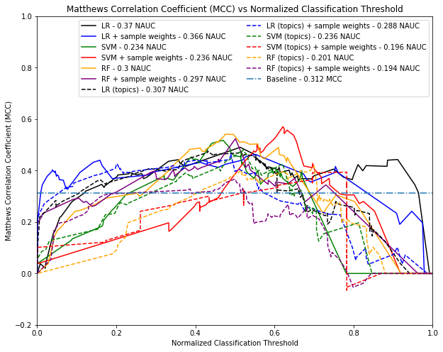

```python
ax = plot_mccs(classifiers, X_validation)
ax = plot_mccs(classifiers_topics, X_validation_topics, linestyle='dashed', ax=ax)
baseline_mcc = matthews_corrcoef(y_validation, X_validation.num_workplaces_at_least_2)
ax.axhline(y=baseline_mcc, linestyle='-.',
           label='Baseline' + ' - {} MCC'.format(round(baseline_mcc, 3)))
ax.set_xlim(0.0, 1.0)
ax.set_ylim(-0.2, 1.0)
ax.set_xlabel('Normalized Classification Threshold')
ax.set_title('Matthews Correlation Coefficient (MCC) vs Normalized Classification Threshold')
ax.legend(ncol=2);
```

We can make the following observations about the chart:

1. All of the models beat the naive baseline classifier over at least some range of classification thresholds. As such we can conclude that machine learning is appropriate for this task.
2. All $NAUC_{MCC}$'s are significantly greater than zero. This lends further support to the first point. It looks like there is some signal in the data for predicting the target. However, the low values indicate that the majority of the classifiers are weak.
3. The logistic regression classifiers perform better than the random forest classifiers, which in turn, perform better than the support vector machine classifiers.
4. Performance of the classifiers trained with the topics features are worse than those trained with the original features. It seems like some important information was lost during topic modeling.
5. The effect of the sample weights varies with classifier type and feature type. Using sample weights improves the performance of the SVM classifier when using the original features. However, sample weights worsen the performance when topics features are used or the classifier is a logistic regression or random forest. Although, the difference is very small for the original features.

Clearly we should select the logistic regression classifier as it is the best performer based on $NAUC_{MCC}$.

## Optimal Classification Threshold

Our work is not quite done yet as we still have to choose an optimal classification threshold for the **LR classifier**. Below we plot the classification threshold against the Matthews Correlation Coefficient (MCC), true positive rate (TPR) and true negative rate (TNR) to help us with this selection. Naturally, there is a tradeoff between the TPR and the TNR. Minimizing false positives (i.e. maximizing the TNR) is more important than minimizing false negatives (i.e. maximizing the TPR) when classifying the physicists as laureates and non-laureates. This is because we are trying to gain insight into any kinds of biases that may involved when a physicist is awarded the Nobel Prize. So any threshold to the right of the intersection of the TPR and TNR would satisfy this criteria. However, we must also ensure that we retrieve as many of the true positives as possible so that the conclusions we draw are based on a large as possible sample of *actual* laureates. So intuitively, the threshold corresponding to the maximum value of the MCC, seems to be a good choice for the optimal classification threshold.

```python
def plot_mcc_tpr_tnr(clf, X, ax=None):
    """Plot the Matthew Correlation Coefficients (MCC), true positive rate (TPR) and true negative rate
        (TNR) as a function of the classification threshold for a classifier.

    Args:
        clf ([type]): [description]
        X ({array-like, sparse matrix}, shape (n_samples, n_features)): Features matrix, where n_samples
            is the number of samples and n_features is the number of features.
        ax (matplotlib.axes.Axes, optional): Defaults to None. axes.

    Raises:
        NotImplementedError: Raises if classifier does not have `predict_proba` or `decision_function`
            attribute.

    Returns:
        matplotlib.axes.Axes): axes.

        float: Threshold corresponding to maximum MCC.
    """

    if not ax:
        fig, ax = plt.subplots(figsize=(8, 6))

    best_classifier = clf['best_classifier']
    if hasattr(best_classifier, 'predict_proba'):
        y_score = best_classifier.predict_proba(X)[:, 1]
        probability = True
    elif hasattr(best_classifier, 'decision_function'):
        y_score = best_classifier.decision_function(X)
        probability = False
    else:
        raise NotImplementedError
    mcc, tnr, tpr, thresholds = mcc_curve(y_true=y_validation, y_score=y_score, probability=probability)

    ax.plot(thresholds, mcc, color='black', label='Matthews Correlation Coefficient (MCC)')
    ax.plot(thresholds, tpr, color='blue', label='True Positive Rate (TPR)')
    ax.plot(thresholds, tnr, color='green', label='True Negative Rate (TNR)')

    max_mcc_idx = np.argmax(mcc)
    ax.axvline(thresholds[max_mcc_idx], color='red', linestyle='dashed', linewidth=1.0,
               label='Max MCC = {} (threshold = {})'.format(round(np.max(mcc), 3),
                                                            round(thresholds[max_mcc_idx], 3)))
    ax.set_xlim(0.0, 1.0)
    ax.set_ylim(0.0, 1.0)

    ax.set_xlabel('Classification Threshold')
    ax.set_title('Matthews Correlation Coefficient (MCC) / True Positive Rate (TPR) \n'
                 '/ False Negative Rate (FNR) vs Classification Threshold')
    ax.legend()

    return ax, thresholds[max_mcc_idx]
```

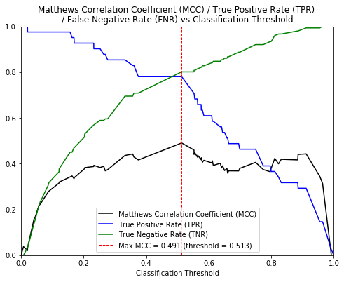

```python
_, optimal_threshold = plot_mcc_tpr_tnr(logit_results, X_validation);
```

Or alternatively, if you prefer, the confusion matrix and the classification report of this classifier tell a similar story to that described above.

```python
best_classifier = logit_results['best_classifier']
y_pred = (best_classifier.predict_proba(X_validation)[:, 1] > optimal_threshold).astype('int64')
display(confusion_matrix_to_dataframe(confusion_matrix(y_validation, y_pred)))
print(classification_report(y_validation, y_pred))
```

|  | Predicted negative | Predicted positive | Observed total |
| --- | --- | --- | --- |
| Observed negative | 121 | 30 | 151 |
| Observed positive | 10 | 31 | 41 |
| Predicted total | 131 | 61 | 192 |

```
              precision    recall  f1-score   support

           0       0.92      0.80      0.86       151
           1       0.51      0.76      0.61        41

   micro avg       0.79      0.79      0.79       192
   macro avg       0.72      0.78      0.73       192
weighted avg       0.83      0.79      0.80       192
```

## Persisting the Best Classifier Parameters

Now we have the best classifier, let's persist it's parameters and associated metadata, which will allow us to reconstruct the classifier at any point in the future. Note that we are not persisting the actual sklearn estimator using [joblib](https://pypi.org/project/joblib/) or [pickle](https://docs.python.org/3/library/pickle.html) as we would like to avoid any [compatibility or security issues](https://stackabuse.com/scikit-learn-save-and-restore-models/#compatibilityissues).

```python
best_classifier_params = pd.Series(
    type(best_classifier), name=logit_results['name'].replace(' ', '_'), index=['estimator'])
best_classifier_params['params'] = best_classifier.get_params()
best_classifier_params['threshold'] = optimal_threshold
best_classifier_params
```

```
estimator    <class 'sklearn.linear_model.logistic.Logistic...
params       {'C': 2.0, 'class_weight': {0: 0.1, 1: 0.9}, '...
threshold                                             0.513453
Name: LR, dtype: object
```

```python
best_classifier_params.to_csv('../models/' + best_classifier_params.name + '.csv', header=True)
```

As a sanity check, let's recreate the estimator and make sure that we get the same results as before.

```python
best_classifier_params_check = pd.read_csv('../models/' + best_classifier_params.name + '.csv',
                                           squeeze=True, index_col=0)
best_classifier_params_check
```

```
estimator    <class 'sklearn.linear_model.logistic.Logistic...
params       {'C': 2.0, 'class_weight': {0: 0.1, 1: 0.9}, '...
threshold                                   0.5134529676865361
Name: LR, dtype: object
```

```python
best_classifier_check = LogisticRegression(**ast.literal_eval(best_classifier_params_check.params))
best_classifier_check.fit(X_train, y_train)
```

```
LogisticRegression(C=2.0, class_weight={0: 0.1, 1: 0.9}, dual=False,
          fit_intercept=True, intercept_scaling=1, max_iter=1000,
          multi_class='warn', n_jobs=None, penalty='l2', random_state=0,
          solver='liblinear', tol=0.0001, verbose=0, warm_start=False)
```

```python
assert(np.array_equal(best_classifier_check.predict(X_validation), best_classifier.predict(X_validation)))
np.testing.assert_allclose(best_classifier_check.predict_proba(X_validation),
                           best_classifier.predict_proba(X_validation))
y_pred_check = (
    (best_classifier_check.predict_proba(
        X_validation)[:, 1] > best_classifier_params.threshold).astype('int64'))
assert(np.array_equal(y_pred_check, y_pred))
```

Great, everything looks good.